# Progetto

Simone Gervasoni Angelo Cardinale Riccardo Bonamoni

2024-04-05

```r
library(tidyverse)
library(mclust)
library(Rmixmod)
library(GGally)
library(caret)
library("tree")
library(ggcorrplot)
library(class)
library(nnet)
library(car)
#install.packages("hunspell")
```

# 1 Abstract

In questo progetto viene analizzato un dataset contenente diverse tipologie di vetri. L’obiettivo è la classificazione di diversi vetri in studio, tramite l’analisi del loro indice di rifrazione e di alcuni elementi chimici presenti. Nel lavoro verranno utilizzate e confrontate diverse tecniche di classificazione con lo scopo di individuare la più accurata.

# 2 Introduzione

Il vetro è un materiale solido che viene detto amorfo, in quanto si comporta come un solido a temperatura ambiente, ma possiede a livello microscopico una struttura disordinata e rigida, al contrario della struttura ordinata dei normali solidi. Il vetro deriva infatti dalla solidificazione di un liquido. I normali vetri sono prevalentemente costituiti da ossido di silicio, ma spesso in fase di produzione vengono aggiunte altre sostanze che ne vanno a modificare le proprietà e le funzioni.

La previsione della tipologia di certi vetri può essere rilevante in alcuni ambiti. I dati utilizzati in questo progetto erano infatti stati raccolti con la finalità di indagini di criminologia. Tramite lo studio della classificazione del tipo di vetro è infatti possibile ottenere diverse evidenze. Ad esempio, un bicchiere sulla scena di un crimine può essere usato come una prova. Altre ricerche, della University of California, sono volte, tramite la classificazione, a determinare se un determinato vetro sia float o meno. Il vetro float, o vetro galleggiante, è infatti ad oggi il vetro più prodotto e utilizzato sul mercato. Grazie alle sue qualità è infatti ideale per diverse applicazioni come vetri per automobili, specchi, finestre o porte, ma anche per la produzione di vetri più specializzati come quello temperato, smerigliato, laminato o insonorizzato.

Il fine del progetto è quindi quello di trovare modelli che classifichino, con maggiore precisione possibile, la tipologia di ciascun vetro, data la sua composizione e analisi chimica.

# 3 Materiali

Il dataset impiegato, *Glass Classification* è stato scaricato dalla piattaforma Kaggle. Proviene dalla USA Forensic Science Service ed è messo a disposizione anche dalla University of California, le quali lo hanno utilizzato per le indagini e analisi di cui sopra.

La matrice dei dati è composta da 214 osservazioni e 10 variabili, riportate di seguito.

- RI: l’indice di rifrazione del vetro, una grandezza adimensionale
- 8 elementi chimici, tutti espressi in percentuale in peso all’interno dell’ossido corrispondente.
  - Na: Sodio
  - Mg: Magnesio
  - Al: Alluminio
  - Si: Silicio
  - K: Potassio
  - Ca: Calcio
  - Ba: Bario
  - Fe: Ferro
- Type : La tipologia di vetro, è la **variabile target**. È suddivisa in 7 classi.
  1. building_windows_float_processed
  2. building_windows_non_float_processed
  3. vehicle_windows_float_processed
  4. vehicle_windows_non_float_processed
  5. containers
  6. tableware
  7. headlamps

La variabile target è analizzata come un *Factor* in R. Per la classe 4 non sono presenti valori nel dataset.

Sono state effettuate analisi per il controllo di valori mancanti ed è stato riscontrato che non sono presenti rendendo quindi non necessarie tutte le tecniche volte all’imputazione o rimozione di essi.

# 4 Preprocessing

## 4.1 Analisi esplorativa

```r
path <- "glass.csv"
glass <- tibble(read.table(path , sep = "," , header = T))
glass$Type <- factor(glass$Type)
n<-nrow(glass)
k<-ncol(glass)
```

In questa fase di preprocessing, come primo step, è stato diviso il dataset in training e test. Il training rappresenta un 80% casuale dei nostri dati, mentre il test il restante 20%. Le analisi, sia descrittive che grafiche, svolte successivamente sono applicate solamente al dataset di training, escludendo momentaneamente il test set ed utilizzandolo unicamente per la valutazione finale. In questo modo le analisi svolte non saranno in alcun modo influenzate da questo dataset come se stessimo applicando il modello nella realtà

```r
#implementiamo una funzione per suddividere in train set e test set
dataset_division <- function(D1, perc = 0.8) {
  set.seed(42)
  id <- sample(size = round(perc* nrow(D1)) , x = nrow(D1))
  train <- D1[id,]
  test <- D1[-id,]
  out <- list(train = train, test = test)
}

division<-dataset_division(glass)
glass.train <- division$train
glass.test <- division$test
```

Innanzitutto, è rappresentata la matrice di correlazione tra tutte le nostre variabili, tutte quantitative, esclusa ovviamente la variabile target. Si nota una forte correlazione positiva tra Ca e RI. Questa correlazione potrebbe creare problemi in metodi come il KNN e verrà quindi successivamente approfondita.

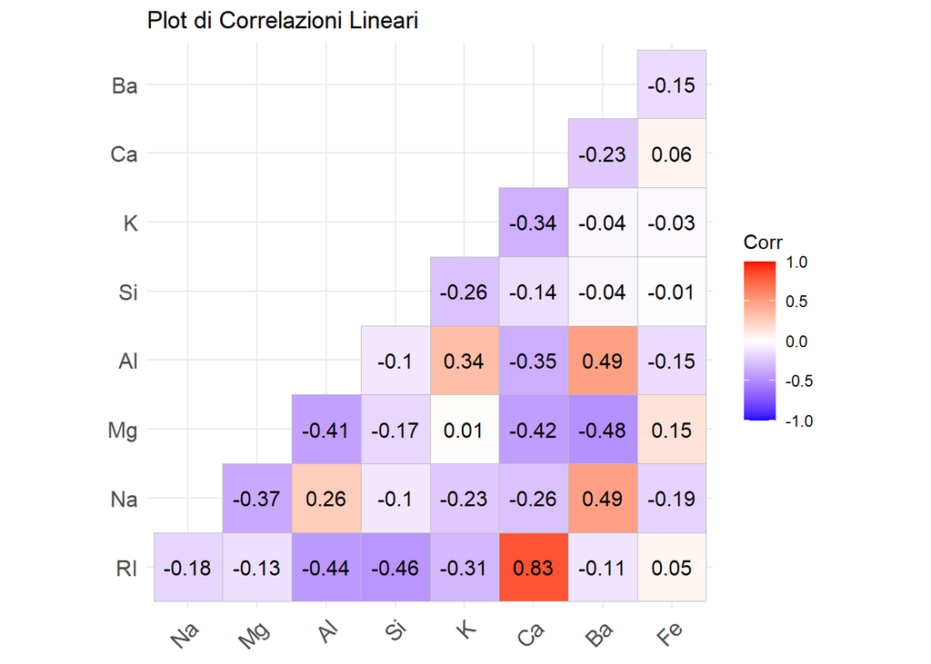

```r
ggcorrplot(cor(glass.train%>%
 select(-Type)), lab = T , type = "lower" ) +
  labs(title = "Plot di Correlazioni Lineari")
```

Successivamente è visualizzato l’istogramma relativo alle frequenze relative delle 7 classi della variabile target *Type*. Si ricorda che la quarta classe non è presente, riducendo a 6 classi la nostra analisi.

Si nota facilmente come le prime due classi siano molto più presenti delle altre. Infatti, solo queste due rispecchiano circa il 65% di tutte le osservazioni. Questa situazione si identifica nel problema di classi sbilanciate, ovvero quando nel set di dati di addestramento (training set) i dati non ugualmente distribuiti tra le classi, causando verosimilmente minor accuratezza nel modello. In questi contesti è solito cercare di bilanciare le classi, tramite tecniche di oversampling (SMOTE) o undersampling, in particolare se si ritiene di una certa importanza individuare determinate classi meno presenti. Tuttavia, successivamente ad alcune ricerche, non è stato ritenuto opportuno applicare queste tecniche al dataset in analisi. Infatti, non è presente nessuna classe di tipologia di vetri più rilevante rispetto ad altre.

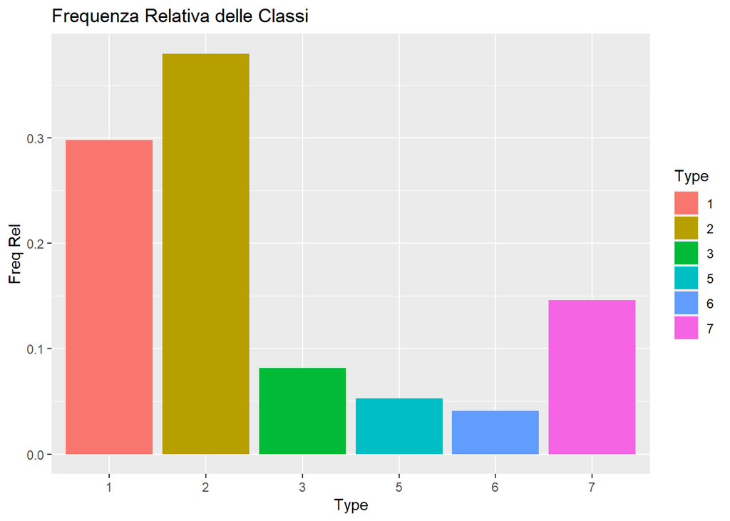

```r
#bar plot freq relative
glass.train %>%
  ggplot(aes(x = Type, y = after_stat(count)/sum(after_stat(count)), fill = Type)) +
  geom_bar() +
  labs(title = "Frequenza Relativa delle Classi",y = "Freq Rel")
```

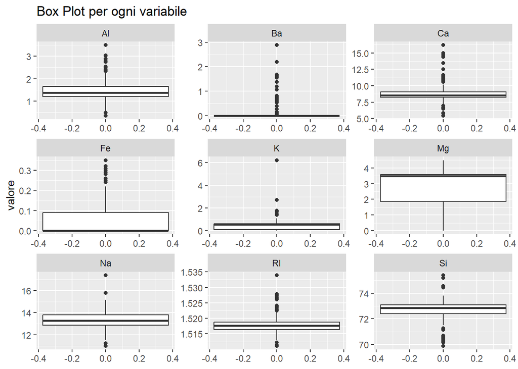

```r
glass.train %>%
  select(-Type)%>%
  gather(key = tipo, value=valore)%>%
  ggplot(mapping= aes(y = valore)) +
  geom_boxplot()+
  facet_wrap(~ tipo,scales="free")+
  labs(title = "Box Plot per ogni variabile")
```

È utile osservare anche il Violin plot delle variabili condizionato alle classi. Ciò permette di vedere una stima della densità non parametrica delle distribuzioni di ogni variabile rispetto alle classi. Tramite questo grafico si riescono infatti a fare 3 principali osservazioni:

- La varianza e la scala delle variabili sono diverse tra di loro: questo porterà a effettuare una normalizzazione, utile per esempio quando verrà applicato l’algoritmo K-NN.
- La varianza per ogni classe per ognuna delle variabili è diversa: questo porta ad escludere l’utilizzo dell’analisi discriminante lineare (LDA), in quanto ipotesi necessaria di essa.
- La distribuzione condizionata per ogni variabili non sembra essere quasi mai normale: viene quindi rifiutata anche l’analisi discriminante quadratica (QDA), oltre a LDA. Si conferma inoltre l’asimmetria.

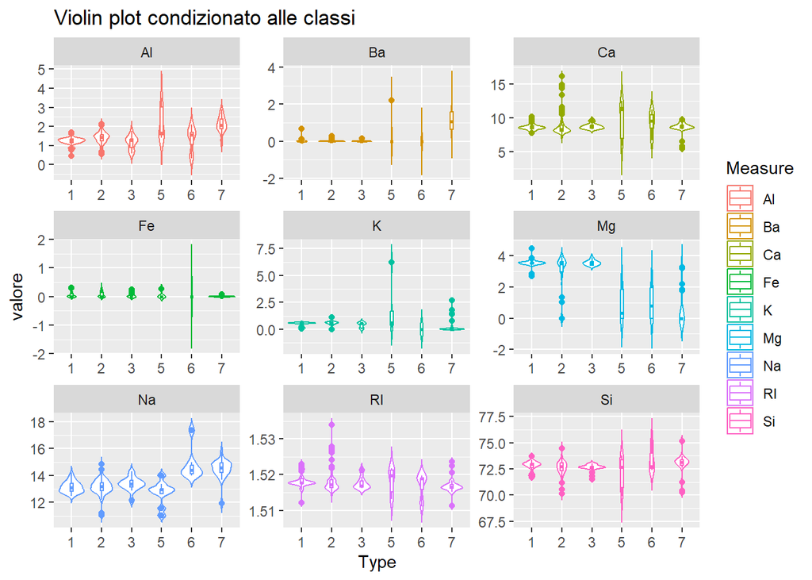

```r
glass.train %>%
  gather(key = Measure, value = valore, -Type )  %>%
  ggplot(aes(x = Type, y= valore, color = Measure)) +
  geom_violin(trim = F)+
  geom_boxplot(width=0.1) +
  facet_wrap( ~ Measure ,scales = "free", ncol =3)+
  labs(title = "Violin plot condizionato alle classi")
```

Si nota inoltre tramite il seguente tibble che, per la classe Type = 6, le variabili *Ba*, *Fe* e *K* non variano e sono tutte pari a zero. Si tratta degli stessi 3 elementi chimici che presentano la distribuzione più asimmetrica e verranno in seguito trattati.

```r
glass.train %>%
  filter(Type == "6")
```

```
# A tibble: 7 × 10
     RI    Na    Mg    Al    Si     K    Ca    Ba    Fe Type
  <dbl> <dbl> <dbl> <dbl> <dbl> <dbl> <dbl> <dbl> <dbl> <fct>
1  1.52  14.6  0     0.56  73.5     0 11.2      0     0 6
2  1.51  17.4  0     0.34  75.4     0  6.65     0     0 6
3  1.52  14.2  0     2.09  72.7     0 10.9      0     0 6
4  1.52  14.1  2.19  1.66  72.7     0  9.32     0     0 6
5  1.52  14    2.39  1.56  72.4     0  9.57     0     0 6
6  1.51  14.4  1.74  1.54  74.6     0  7.59     0     0 6
7  1.52  15.0  0.78  1.74  72.5     0  9.95     0     0 6
```

Dai violin plot sembrerebbe che alcuni valori possano essere negativi, che sarebbe impossibile per le nostre variabili, ma questo è dovuto solo a causa della stima delle distribuzioni. Di seguito è riportata comunque una verifica pratica nel nostro training set andando a cercare tutte le osservazioni con valori positivi. L’output fornisce un tibble con tutte le 171 osservazioni del training, ovvero l’80% del dataset completo, andandoci a confermare che non siamo in presenza di valori negativi.

```r
glass.train %>%
  filter(if_any("RI" : "Fe", ~ . > 0 ))
```

```
# A tibble: 171 × 10
      RI    Na    Mg    Al    Si     K    Ca    Ba    Fe Type
   <dbl> <dbl> <dbl> <dbl> <dbl> <dbl> <dbl> <dbl> <dbl> <fct>
 1  1.52  13.2  3.77  0.79  72.0  0.13 10.0   0     0    1
 2  1.52  13.5  3.74  0.9   72.0  0.18  9.61  0     0.07 1
 3  1.52  13.6  3.65  0.65  73    0.06  8.93  0     0    3
 4  1.52  13.3  3.57  1.57  72.9  0.61  7.89  0     0    2
 5  1.52  12.8  3.67  1.24  72.6  0.62  8.68  0     0.35 2
 6  1.52  12.9  3.54  1.62  73.0  0.64  8.03  0     0.21 2
 7  1.52  14.2  0     2.08  73.4  0     8.62  1.67  0    7
 8  1.52  13.8  2.28  1.43  72.0  0.49  9.85  0     0.17 2
 9  1.52  13.2  3.37  1.18  72.7  0.57  8.83  0     0.16 1
10  1.52  12.8  3.57  1.35  73.0  0.62  8.59  0     0    1
# ℹ 161 more rows
```

Si riportano infine i grafici della stima delle distribuzioni di ogni variabile, condizionata ad ognuna delle 6 classi presenti. Questi grafici confermano i medesimi risultati e osservazioni dei violin plot visualizzati precedentemente.

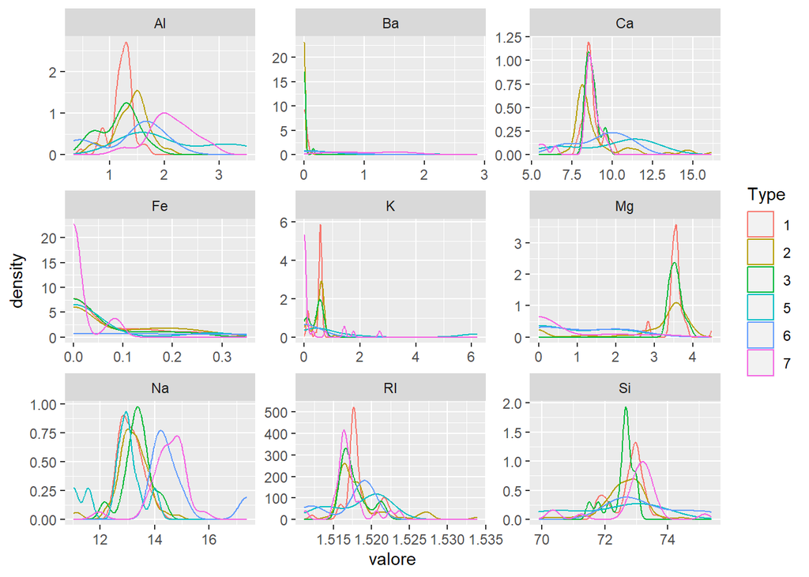

```r
glass.train %>%
  gather(key = Measure, value = valore, -Type )  %>%
  ggplot(aes(x= valore , color = Type)) +
  geom_density() +
  facet_wrap(~Measure, scales= "free")
```

## 4.2 Trasformazione variabili

In una seconda fase del preprocessing si procede con delle trasformazioni opportune delle variabili. La trasformazione applicata è stata quella di Box-Cox dato che si tratta di una trasformazione molto completa e utile che include sia il logaritmo che le trasformazioni potenza, in base ad un parametro $\lambda$. Si è deciso di non trasformare le 3 variabili *Ba*, *Fe* e *K* analizzate precedentemente. Queste presentavano valori non solo asimmetrici, ma molto spostati verso lo zero, rendendo quindi ininfluenti e inutili le trasformazioni.

Il dataset è stato quindi diviso in due gruppi:

- Il primo contiene tutte le 9 variabili non trasformate
- Il secondo ha invece le 6 variabili trasformate, con l’esclusione delle 3 sopraccitate.

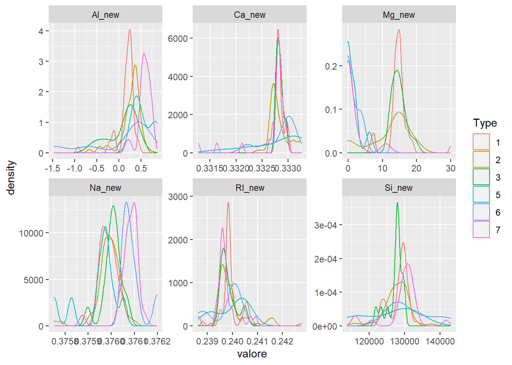

```r
p.train <-glass.train %>%
  select( -c("Fe", "K" , "Ba", "Type"))
p.test <-glass.test %>%
  select( -c("Fe", "K" , "Ba", "Type"))
p.exp <- p.train %>%
  apply(MARGIN =2 , FUN = powerTransform, family = "bcnPower")
a3 <- as.vector(c( p.exp$RI[1]$lambda,p.exp$Na[1]$lambda , p.exp$Mg[1]$lambda, p.exp$Al[1]$lambda, p.exp$Si[1]$lambda,p.exp$Ca[1]$lambda))

transformed.train <- bcPower(with(p.train, cbind(RI, Na, Mg, Al, Si, Ca)),
                lambda = a3 ,gamma= 0.01)
transformed.test <- bcPower(with(p.test, cbind(RI, Na, Mg, Al, Si, Ca)),
                lambda = a3 ,gamma= 0.01)

transformed.glass.train <- tibble(cbind(as.data.frame(transformed.train)), Type = glass.train$Type)
colnames(transformed.glass.train)<-c("RI_new","Na_new","Mg_new","Al_new","Si_new","Ca_new","Type")
transformed.glass.test <- tibble(cbind(as.data.frame(transformed.test)), Type = glass.test$Type)
colnames(transformed.glass.test)<-c("RI_new","Na_new","Mg_new","Al_new","Si_new","Ca_new","Type")

transformed.glass.train%>%
  gather(key = Measure, value = valore, -Type )  %>%
  ggplot(aes(x= valore , colour= Type)) +
  geom_density() +
  facet_wrap(~Measure, scales= "free")
```

Si procede con lo studio della normalità tramite appositi test. Viene utilizzato il Test di Shapiro-Wilk che verifica tramite l’ipotesi nulla la normalità del campione. Sono di seguito riportate le due tabelle per ognuno dei due gruppi:

In entrambi i casi si osserva che i p-value sono quasi tutti molto “bassi” facendo rifiutare l’ipotesi nulla di normalità. Vengono quindi confermati analiticamente i risultati ottenuti prima tramite le analisi grafiche, portando all’esclusione di LDA e QDA.

```r
pvalue.shapiro <- matrix(0, nrow = (dim(glass.train)[2]-1), ncol = 6)
rownames(pvalue.shapiro) = colnames(glass.train)[-10]
colnames(pvalue.shapiro) = levels(glass.train$Type)
#-----

# Test Shapiro e costruzione di una matrice riassuntiva con i p-value condizionati alla classe
for (i in colnames(glass.train)[-10]){
  for (j in levels(glass.train$Type)){
    pvalue.shapiro[i,j]<-
      shapiro.test( jitter(glass.train %>% filter(Type == j)%>%pull(i)) )$p.value #jitter introduce noise gaussiano per evitare errori nel test

  }
}

pvalue.shapiro["Ca", "6" ] <- pvalue.shapiro["K", "6" ] <- pvalue.shapiro["Fe", "6" ] <- NA

round(pvalue.shapiro, 5)
```

```
         1       2       3       5       6       7
RI 0.00002 0.00000 0.00535 0.03417 0.00762 0.00088
Na 0.08159 0.00256 0.63283 0.34926 0.00370 0.00126
Mg 0.00000 0.00000 0.46705 0.02070 0.08438 0.00000
Al 0.00123 0.07349 0.30419 0.01378 0.13011 0.57297
Si 0.00015 0.00069 0.01374 0.16773 0.09874 0.00010
K  0.00000 0.00000 0.00136 0.00042      NA 0.00000
Ca 0.00093 0.00000 0.05860 0.04559      NA 0.00002
Ba 0.00000 0.00000 0.00007 0.00133 0.45231 0.04347
Fe 0.00000 0.00000 0.00007 0.00345      NA 0.00000
```

```r
pvalue.shapiro.2 <- matrix(0, nrow = (dim(transformed.glass.train)[2]-1), ncol = 6)
rownames(pvalue.shapiro.2) = colnames(transformed.glass.train)[-7]
colnames(pvalue.shapiro.2) = levels(transformed.glass.train$Type)
#-----

# Test Shapiro e costruzione di una matrice riassuntiva con i p-value condizionati alla classe
for (i in colnames(transformed.glass.train)[-7]){
  for (j in levels(glass.train$Type)){
    pvalue.shapiro.2[i,j]<-
      shapiro.test( jitter(transformed.glass.train %>% filter(Type == j)%>%pull(i)) )$p.value #jitter introduce noise gaussiano per evitare errori nel test
  }
}

round(pvalue.shapiro.2, 5)
```

```
             1       2       3       5       6       7
RI_new 0.00002 0.00000 0.00559 0.03388 0.00746 0.00097
Na_new 0.30468 0.00000 0.20540 0.08437 0.02077 0.00001
Mg_new 0.00000 0.00000 0.27227 0.00199 0.03073 0.00000
Al_new 0.00000 0.00000 0.02006 0.04347 0.00796 0.00876
Si_new 0.00019 0.00136 0.01500 0.18190 0.10155 0.00014
Ca_new 0.08716 0.00001 0.20838 0.00475 0.04901 0.00000
```

L’ultimo step della fase di Preprocessing è la normalizzazione. Sono di seguito implementate delle funzioni che vanno a normalizzare tutti i nostri dati. Ciò è essenziale per poter successivamente applicare l’algoritmo del K-NN che utilizza le distanze euclidee.

```r
func<-function(v){
  return((v-v[1])/(v[2]-v[1]))
}

# matrix sarà la tabella contenente min e max del train set
norm_aux<-function(data,matrix){
  data_2<-rbind(matrix,data)
  data_norm<-apply(data_2,MARGIN = 2,func)
  return(data_norm[3:nrow(data_norm),])
}

# questa funzione prende sia il train che il test e normalizza il test con min e max del train
normalize<-function(train,test){
  matrix_min_max<-rbind(apply(train,MARGIN = 2,min),apply(train,MARGIN = 2,max))
  train_norm<-norm_aux(train,matrix_min_max)
  test_norm<-norm_aux(test,matrix_min_max)
  return(list(train_norm=train_norm,test_norm=test_norm))
}
```

# 5 Metodi di classificazione

## 5.1 Alberi

Come primo metodo è stato provato quello degli alberi decisionali. Questi infatti non hanno particolari assunzioni preliminari e possono quindi essere applicati al dataset in analisi senza nessun problema. Viene riportato in figura l’albero completo T0 con tutti gli split presenti. Si notano diversi split che sembrano poco utili per la classificazione alla fine dell’albero. Questi risultano infatti nella stessa classe e potrebbero essere in futuro potati tramite tecniche di pruning. La variabile che sembra essere più importante è quella dell’elemento chimico del magnesio, in quanto primo split dell’albero (Mg<2.695).

Questo albero fornisce un’accuratezza iniziale del 60.47 % sul test set e conferma quindi essere un modello da approfondire in seguito.

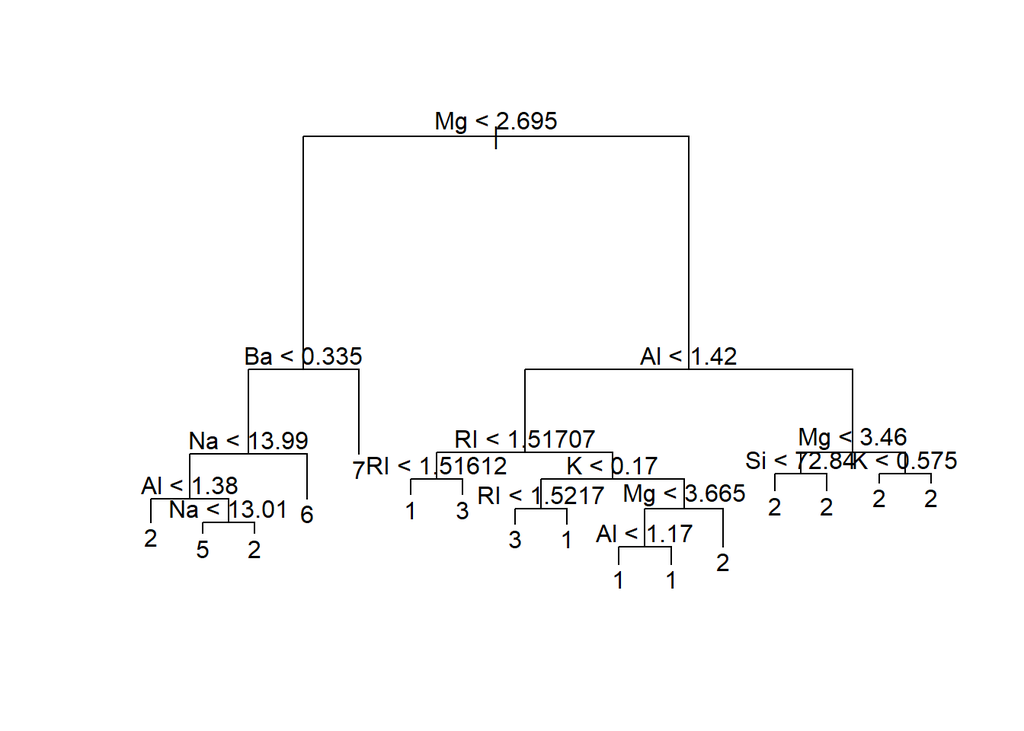

```r
set.seed(47)

tree.glass <- tree(Type ~. , glass.train)
tree.pred <- predict(tree.glass , glass.test[-10] , type = "class")
plot(tree.glass); text(tree.glass, , pretty = 0)
```

```r
mean(tree.pred == glass.test$Type)
```

```
[1] 0.6046512
```

```r
pruned.tree.k <-prune.tree(tree.glass  ,method="misclass")$k
```

## 5.2 KNN

Un secondo possibile metodo è quello dei K-nearest neighbors (K-NN). Per essere applicato è necessaria innanzitutto la normalizzazione di tutti i nostri dati, in modo tale da non avere risultati alterati dalla presenza di variabili con diversi ordini di grandezza. In questa prima fase vengono infatti utilizzate le distanze euclidee come criterio di misura. Una seconda problematica è la elevata multicollinearità riscontrata nella fase di preprocessing tra le variabili *Ca* e *RI*. A livello teorico una di queste due variabili andrebbe quindi omessa, ma in seguito ad analisi approfondite è risultato più performante un modello basato sulla presenza di entrambe le variabili.

Dopo aver verificato e risolto tutte le problematiche relative alla verifica delle assunzioni si può quindi procedere alla ricerca del k ottimale, ricercato tra 1 e 20. Tramite il test set si trova l’iperparametro k che va massimizzare l’accuracy. Viene riportato un grafico che va a mostrare per ogni k possibile la relativa media di osservazioni predette correttamente, individuando in k=8 l’accuratezza più elevata.

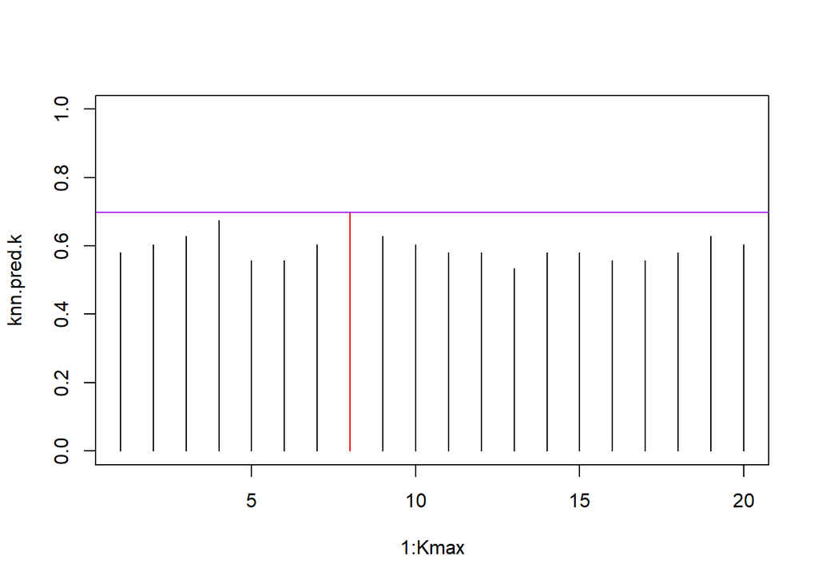

```r
Kmax<-20
out<-normalize(glass.train[,-10],glass.test[,-10])
set.seed(101)
knn.pred.k<-rep(0,Kmax)
X_train<- out$train_norm
labels<-glass.train$Type
X_test<- out$test_norm
for (i in 1:Kmax){
  knn.pred <- knn(train=X_train, test=X_test, cl=labels, k = i)
  knn.pred.k[i]<-mean(knn.pred == glass.test$Type)
}
r<-rep("black",Kmax)
r[which.max(knn.pred.k)]<-"red"
plot(1:Kmax,knn.pred.k,type="h",ylim=c(0,1),col=r)
abline(h=max(knn.pred.k),col="purple")
```

## 5.3 KNN Mahalanobis

Un approccio alternativo al classico algoritmo del KNN è quello di utilizzare la distanza di Mahalanobis in alternativa alla più comune distanza euclidea. In questo caso non è necessaria la normalizzazione, dato che la distanza di Mahalanobis tiene conto delle correlazioni e include una trasformazione che già pone le variabili sulla stessa scala. Anche in questo caso si riporta lo stesso grafico di prima per mostrare tutti i k possibili e la loro relativa accuratezza.

```r
mahalanobis_dist <- function(x, mean_vec, sigma_inv) {
  diff_vec <- t(t(x) - mean_vec)
  out <- sqrt(as.numeric(t(diff_vec) %*% sigma_inv %*% diff_vec ))
  return(out)
}

find_mode <- function(x) {
  u <- unique(x)
  tab <- tabulate(match(x, u))
  m.out <- sample(u[tab == max(tab)], size = 1)
  m.out
}


predict_label <- function(v, train, mat, k, train_lab) {
  dists <- apply(train, MARGIN = 1, function(x) mahalanobis_dist(x, v, mat))
  check <- data.frame("dist"=dists,"lab"=train_lab)
  check <- as_tibble(check)
  check_ord <-  check  %>% slice_min(dist, n = k)
  return(find_mode(check_ord$lab))
}

# si implementa una funzione per l'applicazione del metodo knn tramite distanza di mahalanobis
knn_mahalanobis <- function(train, valid, train_lab, valid_lab, k) {
  x_matrix_inv <- solve(cor(train))
  pred <- apply(valid, MARGIN = 1, function(x) predict_label(x, train, x_matrix_inv, k, train_lab))
  out <- mean(pred == valid_lab)
  return(out)
}
```

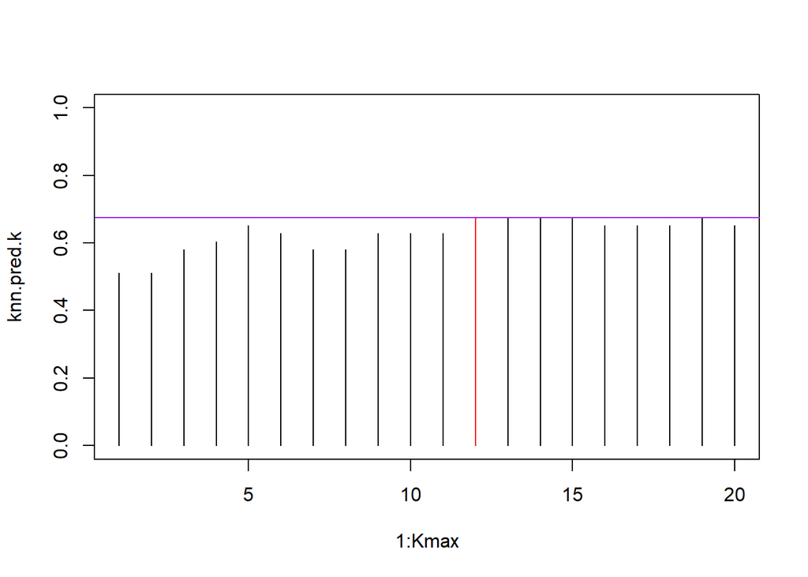

```r
Kmax<-20
set.seed(47)
knn.pred.k<-rep(0,Kmax)
X_train<-glass.train[,-10]
labels.train<-glass.train$Type
labels.test<-glass.test$Type
X_test<-glass.test[,-10]
for (i in 1:Kmax){
  knn.pred.k[i]<-knn_mahalanobis(X_train, X_test, labels.train, labels.test, k=i)
}
r<-rep("black",Kmax)
r[which.max(knn.pred.k)]<-"red"
plot(1:Kmax,knn.pred.k,type="h",ylim=c(0,1),col=r)
abline(h=max(knn.pred.k),col="purple")
```

## 5.4 Confronto metodi

In questo paragrafo si procede quindi con il confronto tra i diversi metodi di classificazione. Nella fase precedente sono stati selezionati 3 diversi metodi:

- Alberi decisionali
- KNN
- KNN con distanze di Mahalanobis

È stata effettuata inoltre una regressione logistica multiclasse, ma è stata esclusa a causa di scarsi risultati che in termini di accuracy si aggiravano attorno al 40%.

In questa fase verrà tuttavia utilizzato un metodo diverso per trovare il modello ottimale, ovvero la tecnica della **cross-validation**. Tramite questo metodo più robusto si riescono a trovare iperparametri migliori sia per gli alberi decisionali che per il KNN. Verrà quindi messo da parte il test set e verrà suddiviso in 5 parti il training set in modo tale da poterci applicare la cross-validation e trovare l’iperparametro ottimale. Ovviamente verranno mantenuti sempre gli stessi gruppi per avere un confronto equo tra i diversi metodi.

Infine è stata calcolata l’accuracy per ognuno dei 3 metodi utilizzando l’iperparametro relativo appena trovato. Sono stati utilizzate tutte e 9 le variabili non trasformate, ovvero quelle del primo gruppo del preprocessing. Viene riportata una semplice tabella riassuntiva dei risultati. Il metodo migliore sembra per ora essere il KNN con distanze euclidee con un’accuracy di 0.66, ma anche gli altri metodi danno buoni risultati intorno al 60%.

```r
cv<-5
p<-1-1/cv
n.train<-nrow(glass.train)
k.train <-ncol(glass.train)
labels.train <-glass.train$Type
knn.kmax<-20
tree.size.max<- length(pruned.tree.k)-2
knn.mahalanobis.max<-20
mat<-as.data.frame(matrix(NA,nrow=(knn.kmax+tree.size.max+knn.mahalanobis.max),ncol=cv+2))
mat[1:knn.kmax,1]<-"knn"
mat[(knn.kmax+1):(knn.kmax+tree.size.max),1]<-"tree"
mat[(knn.kmax+tree.size.max+1):(knn.kmax+tree.size.max+knn.mahalanobis.max),1]<-"knn.maha"
mat[1:knn.kmax,2]<-1:knn.kmax
mat[(knn.kmax+1):(knn.kmax+tree.size.max),2]<- pruned.tree.k[2:(length(pruned.tree.k)-1)]
mat[(knn.kmax+tree.size.max+1):(knn.kmax+tree.size.max+knn.mahalanobis.max),2]<- 1:knn.mahalanobis.max


set.seed(47)
group <- rep(c(1:cv), round(n.train/cv))
random.assign <- sample( c(1:cv),size = n.train - length(group)) # ne mancheranno sempre cv o meno quindi non ci serve replace
split<-sample( append(group, random.assign) , size=n.train)

#loop più grande è quello del cv per ogni split del cv si allenano tutti i modelli con tutti gli iperparametri diversi si calcola l'errore e si passa al successivo blocco di cv
for (j in 1:cv){


  out.norm.cv<-normalize(glass.train[split != j  ,-k.train] ,glass.train[split ==j ,-k.train])
  train.cv<-out.norm.cv$train_norm
  test.cv<-out.norm.cv$test_norm
  #metodo knn
  for (i in 1:knn.kmax){
    knn.pred <- knn(train=train.cv, test=test.cv, cl=labels.train[split != j], k = i)
    mat[i,j+2]<-mean(knn.pred == labels.train[split ==j])
  }


  train.cv.tree <- glass.train[split != j,]
  test.cv.tree  <-glass.train[split ==j,]
  tree.glass.cv <- tree(Type ~. , train.cv.tree)
  #metodo alberi
  for (l in 1:tree.size.max){
    pruned.tree <-prune.tree(tree.glass.cv ,method = "misclass", k = pruned.tree.k[l+1] )
    tree.pred <-predict(pruned.tree , test.cv.tree[,-k.train] , type = "class")
    mat[knn.kmax+l,j+2]<- mean(tree.pred == labels.train[split ==j])
  }

  train.maha <- glass.train[split != j,]
  test.maha <-glass.train[split ==j,]
  #metodo knn con mahalanobis distance
  for (h in 1:knn.mahalanobis.max){
    mat[knn.kmax+tree.size.max+h,j+2]<- knn_mahalanobis(train.maha[,-k.train], test.maha[,-k.train], train.maha$Type, test.maha$Type, k=h)
  }


}
res<-cbind(mat[,c(1,2)],apply(mat[,3:j+2],MARGIN=1,mean))
colnames(res)<-c("metodo","hyperparameter","accuracy")
res<-as_tibble(res)
best.res<-rbind(res%>%filter(metodo=="knn")%>%filter(accuracy==max(accuracy)),
                res%>%filter(metodo=="tree")%>%filter(accuracy==max(accuracy)),
                res%>%filter(metodo=="knn.maha")%>%filter(accuracy==max(accuracy)))
best.res
```

```
# A tibble: 4 × 3
  metodo   hyperparameter accuracy
  <chr>             <dbl>    <dbl>
1 knn                   3    0.660
2 tree                  0    0.612
3 knn.maha              6    0.659
4 knn.maha              7    0.659
```

Si riporta un grafico che rappresenta per ogni metodo l’accuratezza ottenuta con ogni possibile iperparametro. È interessante sottolineare come tutti i metodi preferiscano la scelta di un modello in generale più complesso che rischia di incombere in problemi di overfitting, riscontrando sì un bias inferiore ma trovando molte difficoltà nell’effettuare previsione su dati sconosciuti al modello.

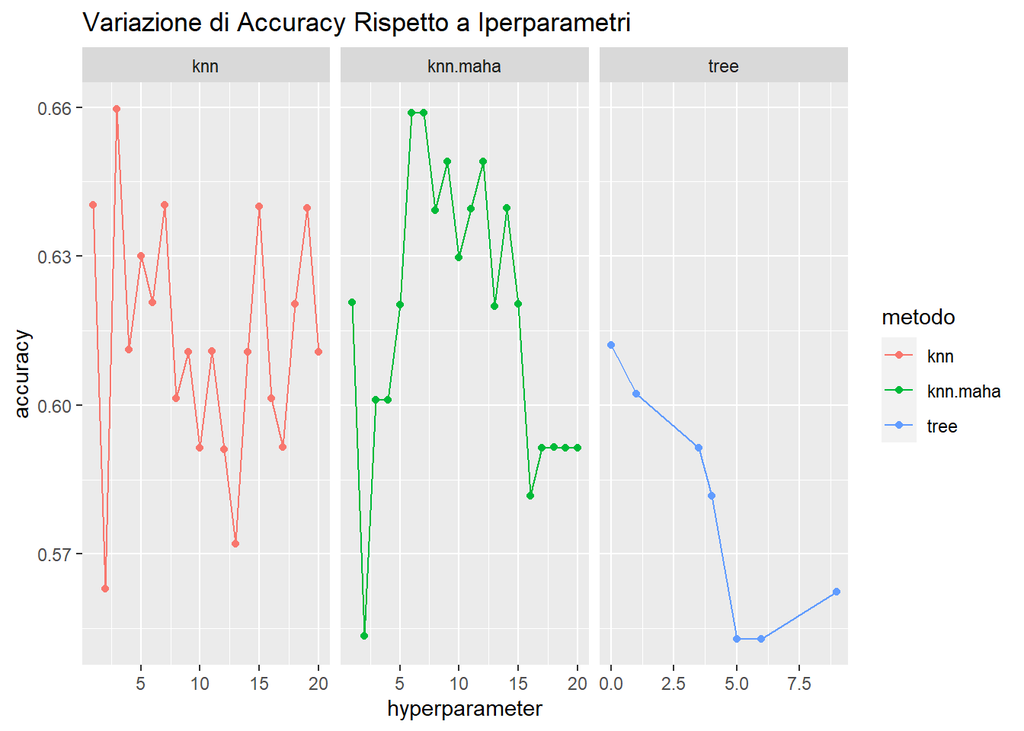

```r
res %>%
  ggplot(mapping  = aes(x = hyperparameter, y= accuracy, color=metodo))  +
  geom_line()+
  geom_point()+
  facet_grid(~metodo, scale  = "free") +
  labs(title= "Variazione di Accuracy Rispetto a Iperparametri")
```

## 5.5 Confronto metodi con Transformed variables

Per ultimare i confronti si procede con l’applicazione dei metodi anche nel secondo gruppo individuato nel preprocessing, ovvero quello con le 6 variabili trasformate e l’esclusione di 3 elementi chimici. Il procedimento è analogo a quanto visto nel capitolo precedente: tramite cross validation sul training, sempre con lo stesso split, vengono trovati i 3 diversi iperparametri relativi ai 3 metodi, per poi calcolarne l’accuracy. Anche in questo caso vengono riportati una tabella riassuntiva ed il grafico con tutti possibili iperparametri e le relative accuracy.

I risultati ottenuti sono deludenti per il KNN con Mahalanobis (accuracy pari a 0.45), mentre sono molto buoni per quanto riguarda il KNN normale (accuracy pari a 0.73).

```r
cv<-5
p<-1-1/cv
n.train<-nrow(transformed.glass.train)
k.train <-ncol(transformed.glass.train)
labels.train <-transformed.glass.train$Type
knn.kmax<-20
tree.size.max<- length(pruned.tree.k)-2
knn.mahalanobis.max<-40
mat.2<-as.data.frame(matrix(NA,nrow=(knn.kmax+tree.size.max+knn.mahalanobis.max),ncol=cv+2))
mat.2[1:knn.kmax,1]<-"knn"
mat.2[(knn.kmax+1):(knn.kmax+tree.size.max),1]<-"tree"
mat.2[(knn.kmax+tree.size.max+1):(knn.kmax+tree.size.max+knn.mahalanobis.max),1]<-"knn.maha"
mat.2[1:knn.kmax,2]<-1:knn.kmax
mat.2[(knn.kmax+1):(knn.kmax+tree.size.max),2]<- pruned.tree.k[2:(length(pruned.tree.k)-1)]
mat.2[(knn.kmax+tree.size.max+1):(knn.kmax+tree.size.max+knn.mahalanobis.max),2]<- 1:knn.mahalanobis.max

set.seed(47)
group <- rep(c(1:cv), round(n.train/cv))
random.assign <- sample( c(1:cv),size = n.train - length(group))
split<-sample( append(group, random.assign) , size=n.train)

#loop più grande è quello del cv per ogni split del cv si allenano tutti i modelli con tutti gli iperparametri diversi si calcola l'errore e si passa al prossimo blocco di cv
for (j in 1:cv){
  out.norm.cv.2<-normalize(transformed.glass.train[split != j  ,-k.train] ,transformed.glass.train[split ==j ,-k.train])
  train.cv<-out.norm.cv.2$train_norm
  test.cv<-out.norm.cv.2$test_norm
  #metodo knn
  for (i in 1:knn.kmax){
    knn.pred <- knn(train=train.cv, test=test.cv, cl=labels.train[split != j], k = i)
    mat.2[i,j+2]<-mean(knn.pred == labels.train[split ==j])
  }


  train.cv.tree <- transformed.glass.train[split != j,]
  test.cv.tree  <-transformed.glass.train[split == j,]
  tree.glass.cv <- tree(Type ~. , train.cv.tree)
  #metodo alberi
  for (l in 1:tree.size.max){
    pruned.tree <-prune.tree(tree.glass.cv ,method = "misclass", k = pruned.tree.k[l+1] )
    tree.pred <-predict(pruned.tree , test.cv.tree[,-k.train] , type = "class")
    mat.2[knn.kmax+l,j+2]<- mean(tree.pred == labels.train[split ==j])
  }
  train.maha <- transformed.glass.train[split != j,]
  test.maha <-transformed.glass.train[split ==j,]
  #metodo knn con mahalanobis distance
  for (h in 1:knn.mahalanobis.max){
    mat.2[knn.kmax+tree.size.max+h,j+2]<- knn_mahalanobis(train.maha[,-k.train], test.maha[,-k.train], train.maha$Type, test.maha$Type, k=h)
  }

}
res.2<-cbind(mat.2[,c(1,2)],apply(mat.2[,3:j+2],MARGIN=1,mean))
colnames(res.2)<-c("metodo","hyperparameter","accuracy")
res.2<-as_tibble(res.2)
best.res.2<-rbind(res.2%>%filter(metodo=="knn")%>%filter(accuracy==max(accuracy)),
                  res.2%>%filter(metodo=="tree")%>%filter(accuracy==max(accuracy)),
                  res.2%>%filter(metodo=="knn.maha")%>%filter(accuracy==max(accuracy)))
best.res.2
```

```
# A tibble: 3 × 3
  metodo   hyperparameter accuracy
  <chr>             <dbl>    <dbl>
1 knn                   2    0.728
2 tree                  0    0.622
3 knn.maha             13    0.446
```

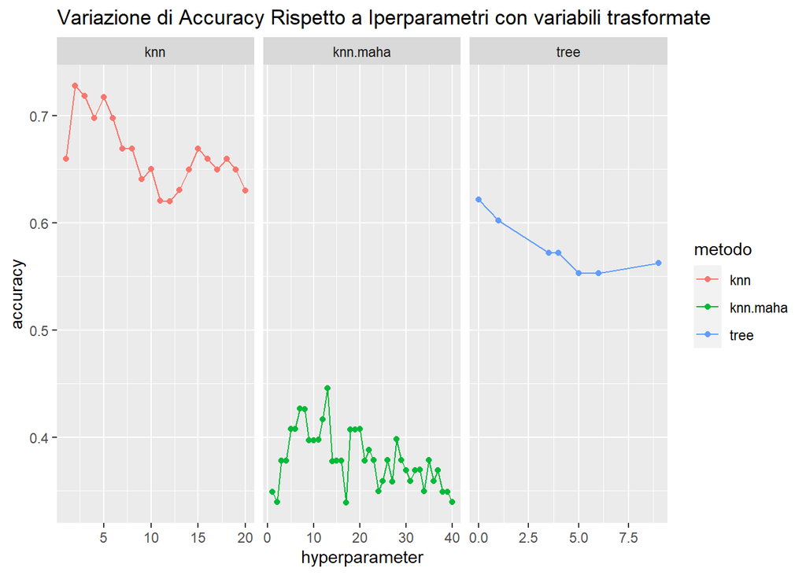

```r
res.2 %>%
  ggplot(mapping  = aes(x = hyperparameter, y= accuracy, color=metodo))  +
  geom_line()+
  geom_point()+
  facet_grid(~metodo, scale  = "free") +
  labs(title= "Variazione di Accuracy Rispetto a Iperparametri con variabili trasformate")
```

# 6 Test e conclusioni

Nella fase conclusiva dell’analisi si riprende quindi il test set col 20% delle osservazioni che erano state lasciate da parte. Si va quindi ad applicare il metodo migliore tra tutti quelli analizzati sul test set. Così facendo si otterrà una vera accuratezza del metodo, dato che il test set non ha interferito nella costruzione di esso.

Sono quindi stati esclusi 3 elementi chimici, ovvero le variabili *Ba*, *Fe* e *K*. Applicando quindi il metodo si ottiene un buon risultato con un’accuracy pari al **72%**. Viene riportata anche la Confusion Matrix. Si nota come il metodo faccia fatica in alcune classi minoritarie, come la terza, probabilmente a causa di poche osservazioni e data la semplicità dell’algoritmo. Tuttavia, questo non risulta essere un problema nelle analisi perché nessun errore ha un peso più alto degli altri, dato che ogni classe ha la stessa importanza, anche in un caso come il nostro con classi leggermente sbilanciate. Avendo a disposizione un maggior numero di dati si potrebbero fare analisi più approfondite su ciascuna delle classi e delle variabili, ovvero sulle varie tipologie di vetro e la loro composizione.

```r
k<-7
out.norm<- normalize(transformed.glass.train[,-k],transformed.glass.test[,-k])
train.norm<-out.norm$train_norm
test.norm<-out.norm$test_norm
labels.train<-transformed.glass.train$Type

set.seed(47)
knn.pred.transf <- knn(train=train.norm, test=test.norm, cl=labels.train, k = 3)
mean(transformed.glass.test$Type == knn.pred.transf)
```

```
[1] 0.7209302
```

```r
reference<-transformed.glass.test$Type
pred.best<-knn.pred.transf
confusionMatrix(data = pred.best,reference = reference, dnn = c("predicted value","true value"))
```

```
Confusion Matrix and Statistics

               true value
predicted value  1  2  3  5  6  7
              1 16  2  3  0  0  1
              2  1  7  0  1  0  0
              3  2  1  0  0  0  0
              5  0  1  0  3  0  0
              6  0  0  0  0  2  0
              7  0  0  0  0  0  3

Overall Statistics

               Accuracy : 0.7209
                 95% CI : (0.5633, 0.8467)
    No Information Rate : 0.4419
    P-Value [Acc > NIR] : 0.0001977

                  Kappa : 0.6003

 Mcnemar's Test P-Value : NA

Statistics by Class:

                     Class: 1 Class: 2 Class: 3 Class: 5 Class: 6 Class: 7
Sensitivity            0.8421   0.6364  0.00000  0.75000  1.00000  0.75000
Specificity            0.7500   0.9375  0.92500  0.97436  1.00000  1.00000
Pos Pred Value         0.7273   0.7778  0.00000  0.75000  1.00000  1.00000
Neg Pred Value         0.8571   0.8824  0.92500  0.97436  1.00000  0.97500
Prevalence             0.4419   0.2558  0.06977  0.09302  0.04651  0.09302
Detection Rate         0.3721   0.1628  0.00000  0.06977  0.04651  0.06977
Detection Prevalence   0.5116   0.2093  0.06977  0.09302  0.04651  0.06977
Balanced Accuracy      0.7961   0.7869  0.46250  0.86218  1.00000  0.87500
```

Si conclude ribadendo che gli altri metodi applicati, ovvero gli alberi decisionali e il KNN con distanze di Mahalanobis hanno portato a risultati peggiori. La regressione logistica multiclasse è stata invece esclusa a priori perché dava risultati ancora peggiori. LDA e QDA sono stati invece esclusi a causa del mancato rispetto delle ipotesi di normalità e di varianza delle classi.

# 7 Bibliografia

[UC Irvine Glass Identification data set](https://archive.ics.uci.edu/dataset/42/glass+identification)

Pilkington Fonte Informazioni su Vetro